title: ‘Assignment 3: Time series prediction with GE’ author: “Benedikt Mueller (201973906)” date: “07/03/2020” output: html_document: toc: true —

# Load libraries

Load packages required to run the code (note: there might be packages that require other packages and specific versions of packages. So if there occurs an error it is most likely due to the aforementioned issue).

```r
suppressPackageStartupMessages(library(gramEvol))
suppressPackageStartupMessages(library(quantmod))
suppressPackageStartupMessages(library(tidyquant))
suppressPackageStartupMessages(library(ggplot2))
suppressPackageStartupMessages(library(reshape2))
suppressPackageStartupMessages(library(gridExtra))
suppressPackageStartupMessages(library(TTR))
suppressPackageStartupMessages(library(dplyr))
suppressPackageStartupMessages(library(reshape2))
suppressPackageStartupMessages(library(forecast))
suppressPackageStartupMessages(library(Metrics))
suppressPackageStartupMessages(library(knitr))
```

# Explorative Analysis

Load data

```r
#setSymbolLookup(QQQ='yahoo',SPY='google')
myStock = tq_get("CL", from = "2015-01-01",to = "2020-01-01", get= "stock.prices")
```

Price chart with simple smoothing (Simple Moving Averages)

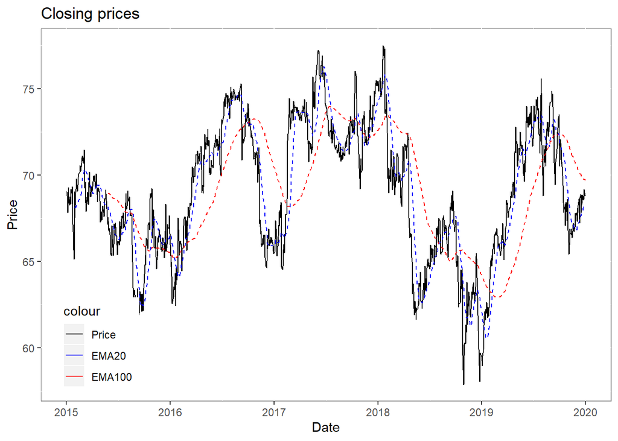

```r
# show price movement
ggplot(data = myStock, aes(x= date, y = close)) +
  geom_line( aes(color = "black")) +
  geom_ma(ma_fun = SMA, n = 100, aes(color = "red")) + # Plot 100-day SMA
  geom_ma(ma_fun = SMA, n = 20, aes(color = "blue")) +
  ggtitle("Closing prices") +
  labs(x = "Date", "Price") +
  scale_x_date(date_breaks = "years", date_labels = "%Y") +
  labs(x = "Date", y = "Price") +
  scale_color_manual(labels = c("Price", "EMA20","EMA100"), values = c("black", "blue", "red")) +
  theme(panel.background = element_rect(fill = "white", colour = "grey50"),legend.position = c(0.1, 0.15))
```

Claculate returns

```r
myReturn = myStock %>%
  tq_transmute(select = "close", mutate_fun = periodReturn, period = "daily", col_rename = "returns")
# and log
myLog = myStock %>%
  tq_transmute(select = "close", mutate_fun = periodReturn,type = "log", period = "daily", col_rename = "lg_returns")
```

Chart of returns (and lg) over given period

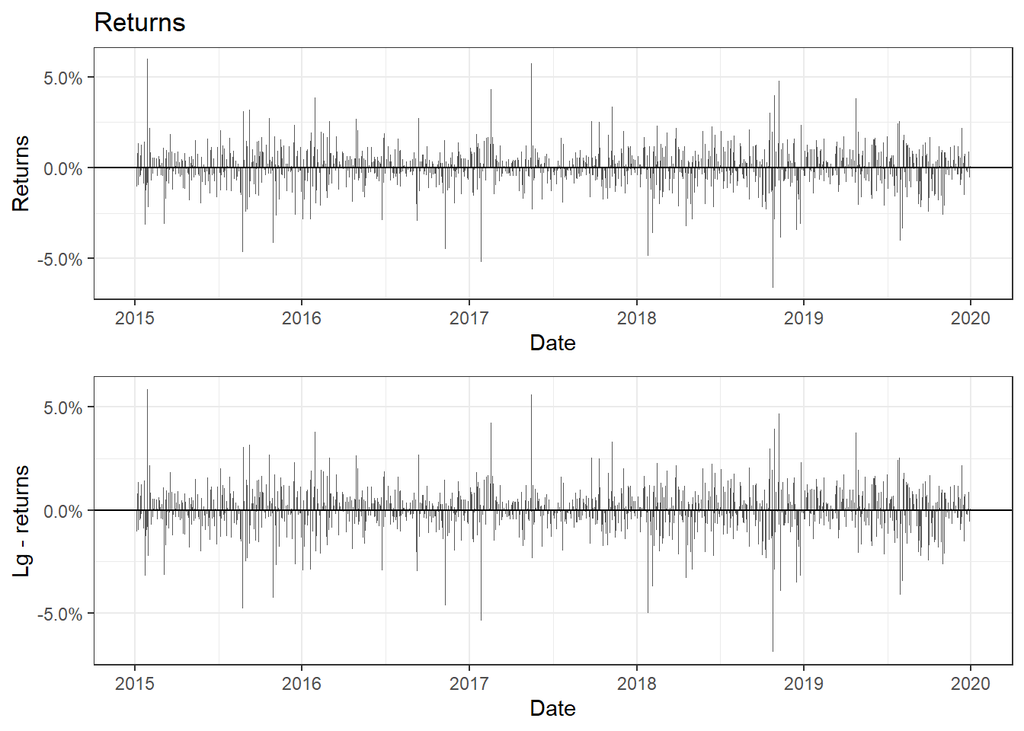

```r
gplt1 = ggplot(data = myReturn, aes(x = date, y = returns)) +
  geom_bar(stat = "identity") +
  geom_hline(yintercept = 0) +
  labs(x = "Date", y = "Returns") +
  ggtitle("Returns") +
  scale_x_date(date_breaks = "years", date_labels = "%Y") +
  scale_y_continuous(breaks = seq(-0.3,0.3,0.05),labels = scales::percent) +
  #scale_fill_discrete(name="Returns",breaks=c("myReturn.retruns", "myLog.lg_returns"),labels=c("normal", "log")) +
  theme_bw()

gplt2 = ggplot(data = myLog, aes(x = date, y = lg_returns)) +
  geom_bar(stat = "identity") +
  geom_hline(yintercept = 0) +
  labs(x = "Date", y = "Lg - returns") +
  scale_x_date(date_breaks = "years", date_labels = "%Y") +
  scale_y_continuous(breaks = seq(-0.3,0.3,0.05),labels = scales::percent) +
  #scale_fill_discrete(name="Returns",breaks=c("myReturn.retruns", "myLog.lg_returns"),labels=c("normal", "log")) +
  theme_bw()
grid.arrange(gplt1, gplt2, nrow=2)
```

Graphs of lg - and return distribution

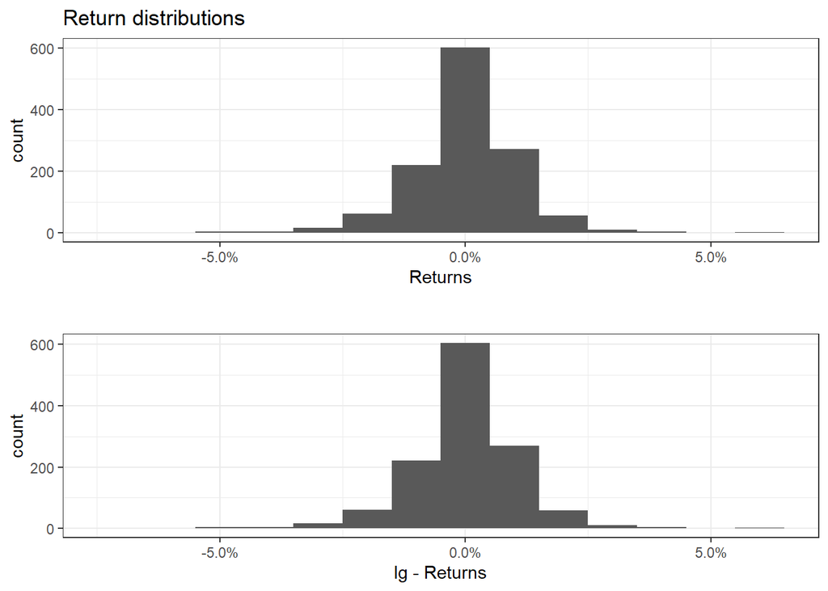

```r
gplt1 = ggplot(data = myLog,aes(x = lg_returns)) +
  geom_histogram(binwidth = 0.01) +
  labs(x = "Returns") +
  ggtitle("Return distributions") +
  scale_x_continuous(breaks = seq(-0.5,0.6,0.05),labels = scales::percent) +
  theme_bw()
gplt2 = ggplot(data = myReturn,aes(x = returns)) +
  geom_histogram(binwidth = 0.01) +
  labs(x = "lg - Returns") +
  ggtitle("") +
  scale_x_continuous(breaks = seq(-0.5,0.6,0.05),labels = scales::percent) +
  theme_bw()
grid.arrange(gplt1, gplt2, nrow=2)
```

Cumulative returns over the selected period

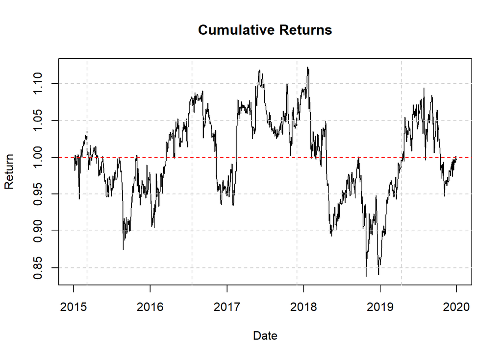

```r
plot(as.Date(myReturn$date),cumprod(1+ myReturn$returns),type="l",lwd=1, col="black",
     xlab="Date",ylab="Return",main="Cumulative Returns")
grid(nx = NULL, ny = NULL, col = "lightgray", lty = "dashed")
abline(h=1, col="red", lty="dashed")
```

Decomposing graphs - showing trends and seasonality (assume additive ts)

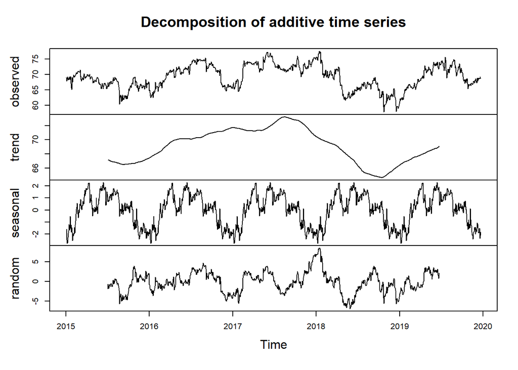

```r
myTs = ts(myStock$close, start = c(2015, as.numeric(format(myStock$date[1], "%j"))),frequency = 253)
#plot(decompose(ts(myStock$close,frequency = 253),type="multiplicative"))
plot(decompose(myTs,type="additive"))
```

The plots indicating a seasonality of 1-yrs size but with a lot of randomness. There is, as expected, an upwards and a downwards trend.  
Inspecting auto correlation

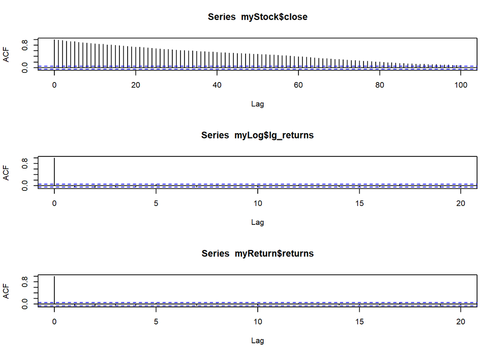

```r
par(mfrow=c(3,1))
acf(myStock$close,lag.max=100)
acf(myLog$lg_returns,lag.max=20)
acf(myReturn$returns,lag.max=20)
```

```r
par(mfrow=c(1,1))
```

As being expected, the prices are highly auto-correlated.

# GE - Setup and Results

```r
#init data
myDataTotal = myStock$close #define dataset

lagData = data.frame(x5=lag(myDataTotal,5), x4=lag(myDataTotal,4), x3=lag(myDataTotal,3),
                     x2=lag(myDataTotal,2), x1=lag(myDataTotal,1), myDataTotal)
names(lagData) = c('x5','x4','x3',"x2","x1",'x')
lagData = lagData[-c(1:5),]


nrows = length(lagData[,1])-round(length(lagData[,1])*0.10,0)
myDataFuture = lagData[-c(1:nrows),]
myDataTrain = lagData[c(1:nrows),]

newRules = list(expr = grule(op(expr, expr), func(expr), var),
                 func = grule(sin, cos, log),
                 op = grule('+', '-', '*', '/', '^'),
                 var = grule(geData$x5, geData$x4,geData$x3, geData$x2, geData$x1))

newGram = CreateGrammar(newRules)

newFitFunc = function(expr) {
  result = eval(expr)
  if (any(is.nan(result)))
    return(Inf)
  return (rmse(geData$x , result))
}

geData = myDataTrain
ge = GrammaticalEvolution(newGram, newFitFunc, terminationCost = 0.001, iterations = 1000, max.depth = 3,
                          disable.warnings=T)#, monitorFunc = print)
ge
```

```
## Grammatical Evolution Search Results:
##   No. Generations:  1000
##   Best Expression:  geData$x1
##   Best Cost:        0.737130420866554
```

See whether the picked equation can depict the ts

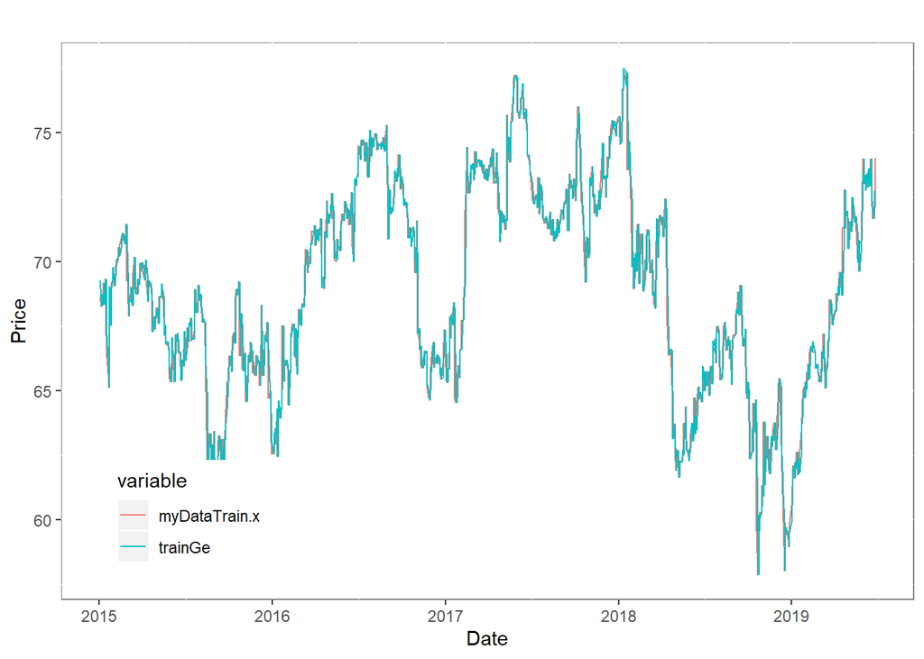

```r
trainGe = eval(ge$best$expressions)

date = myStock$date[c(1:nrows)]
df1 = data.frame(date, myDataTrain$x, trainGe)
df2 = melt(df1, id.vars='date')
ggplot(data = df2, aes(x=date, y=value, col=variable)) +
  geom_line() +
  ggtitle("") +
  labs(x = "Date", "Price") +
  scale_x_date(date_breaks = "years", date_labels = "%Y") +
  labs(x = "Date", y = "Price") +
  theme(panel.background = element_rect(fill = "white", colour = "grey50"),legend.position = c(0.15, 0.15))
```

Now see the predictive power

```r
geData = myDataTrain[length(myDataTrain[,1]-4),1:5]
predictions = c()

for(i in 1:round(length(lagData[,1])*0.10,0)){
  predictions[i] = eval(ge$best$expressions)
  for (cols in (1:(length(geData)-1))){
    geData[cols] = geData[cols+1]
  }
  geData[cols+1] = predictions[i]
}
predictions
```

```
##   [1] 72.74 72.74 72.74 72.74 72.74 72.74 72.74 72.74 72.74 72.74 72.74 72.74
##  [13] 72.74 72.74 72.74 72.74 72.74 72.74 72.74 72.74 72.74 72.74 72.74 72.74
##  [25] 72.74 72.74 72.74 72.74 72.74 72.74 72.74 72.74 72.74 72.74 72.74 72.74
##  [37] 72.74 72.74 72.74 72.74 72.74 72.74 72.74 72.74 72.74 72.74 72.74 72.74
##  [49] 72.74 72.74 72.74 72.74 72.74 72.74 72.74 72.74 72.74 72.74 72.74 72.74
##  [61] 72.74 72.74 72.74 72.74 72.74 72.74 72.74 72.74 72.74 72.74 72.74 72.74
##  [73] 72.74 72.74 72.74 72.74 72.74 72.74 72.74 72.74 72.74 72.74 72.74 72.74
##  [85] 72.74 72.74 72.74 72.74 72.74 72.74 72.74 72.74 72.74 72.74 72.74 72.74
##  [97] 72.74 72.74 72.74 72.74 72.74 72.74 72.74 72.74 72.74 72.74 72.74 72.74
## [109] 72.74 72.74 72.74 72.74 72.74 72.74 72.74 72.74 72.74 72.74 72.74 72.74
## [121] 72.74 72.74 72.74 72.74 72.74
```

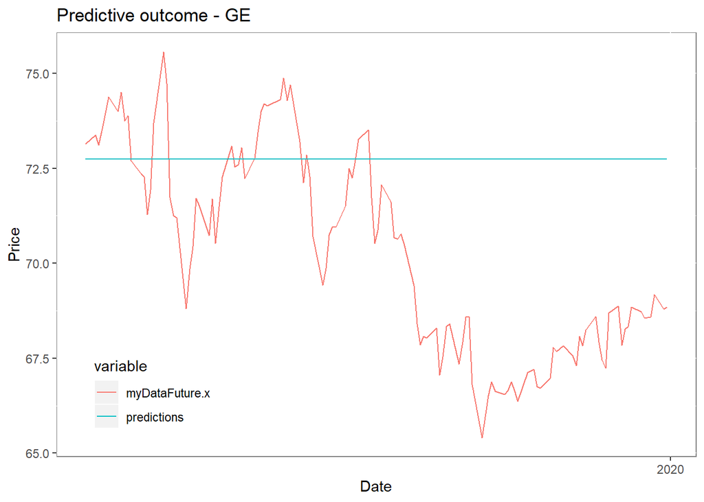

```r
date = myStock$date[-c(1:(nrows+5))]
df1 = data.frame(date, myDataFuture$x, predictions)
df2 = melt(df1, id.vars='date')
ggplot(data = df2, aes(x=date, y=value, col=variable)) +
  geom_line() +
  ggtitle("Predictive outcome - GE") +
  labs(x = "Date", "Price") +
  scale_x_date(date_breaks = "years", date_labels = "%Y") +
  labs(x = "Date", y = "Price") +
  theme(panel.background = element_rect(fill = "white", colour = "grey50"),legend.position = c(0.15, 0.15))
```

```r
ge1_rmse = rmse(predictions,myDataFuture$x)
```

The Ge solution always ends up close to the lag1 parameter. This makes sense since it is sufficent enough to satisfy the given boundaries. Even when trying to lower the penalty (and increasing the iters), the Ge does not come up with any better solution. Also, it does not matter to change the grammars, adding more lags, varying the test size or changing the data to returns (lg or normalizing, respectively)… In the following, the data is changed from daily to weekly, to provide an example to the mentioned problems.

```r
myStockweekly = myStock %>% tq_transmute(select = open:volume, mutate_fun = to.period, period = "weeks")
myDataTotal = myStockweekly$close #define dataset

lagData = data.frame(x3=lag(myDataTotal,3), x2=lag(myDataTotal,2), x1=lag(myDataTotal,1), myDataTotal)
names(lagData) = c('x3',"x2","x1",'x')
lagData = lagData[-c(1:(length(lagData)-1)),]

nrows = length(lagData[,1])-round(length(lagData[,1])*0.10,0)
myDataFuture = lagData[-c(1:nrows),]
myDataTrain = lagData[c(1:nrows),]

newRules = list(expr = grule(op(expr, expr), func(expr), var),
                func = grule(sin, cos, sqrt, log),
                op = grule('+', '-', '*', '/', '^'),
                var = grule(geData$x3^n, geData$x2^n, geData$x1^n),
                n = grule(1,2)) #geData$x5^n, geData$x4^n,
newGram = CreateGrammar(newRules)

geData = myDataTrain
ge = GrammaticalEvolution(newGram, newFitFunc, terminationCost = 0.001, iterations = 5000,disable.warnings=T) #,monitorFunc = print)
ge
```

```
## Grammatical Evolution Search Results:
##   No. Generations:  5000
##   Best Expression:  sqrt(geData$x1^2 - cos(geData$x3^1))
##   Best Cost:        1.54312569603892
```

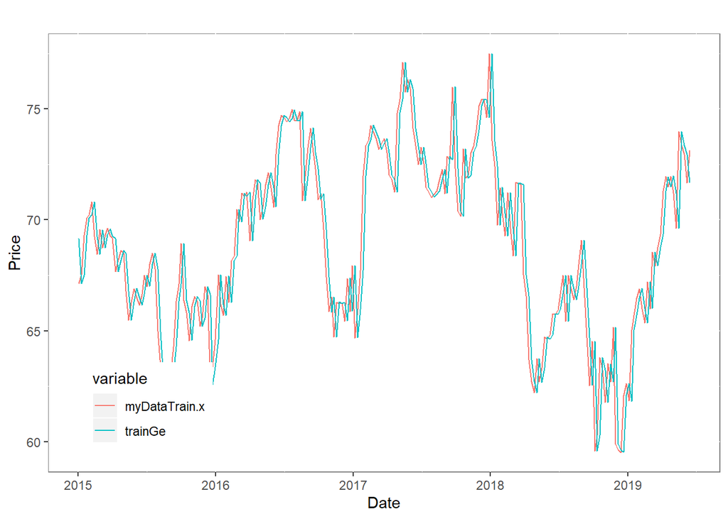

```r
# see matching of Ge-formula with actual data
trainGe = eval(ge$best$expressions)

date = myStockweekly$date[c(1:nrows)]
df1 = data.frame(date, myDataTrain$x, trainGe)
df2 = melt(df1, id.vars='date')
ggplot(data = df2, aes(x=date, y=value, col=variable)) +
  geom_line() +
  ggtitle("") +
  labs(x = "Date", "Price") +
  scale_x_date(date_breaks = "years", date_labels = "%Y") +
  labs(x = "Date", y = "Price") +
  theme(panel.background = element_rect(fill = "white", colour = "grey50"),legend.position = c(0.15, 0.15))
```

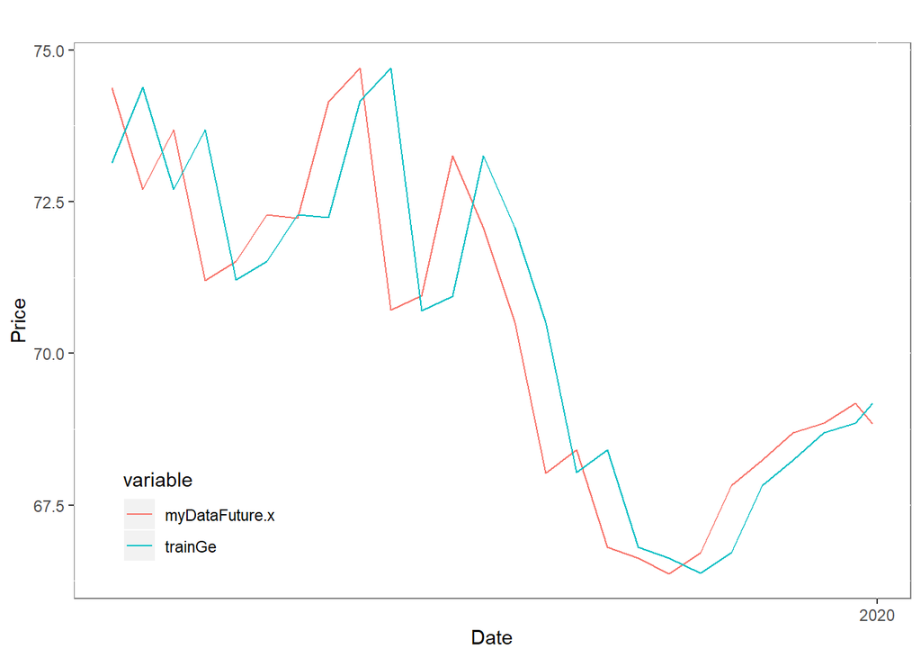

```r
#test formula on unseen data
geData = myDataFuture
trainGe = eval(ge$best$expressions)

date = myStockweekly$date[-c(1:(nrows+3))]
df1 = data.frame(date, myDataFuture$x, trainGe)
df2 = melt(df1, id.vars='date')
ggplot(data = df2, aes(x=date, y=value, col=variable)) +
  geom_line() +
  ggtitle("") +
  labs(x = "Date", "Price") +
  scale_x_date(date_breaks = "years", date_labels = "%Y") +
  labs(x = "Date", y = "Price") +
  theme(panel.background = element_rect(fill = "white", colour = "grey50"),legend.position = c(0.15, 0.15))
```

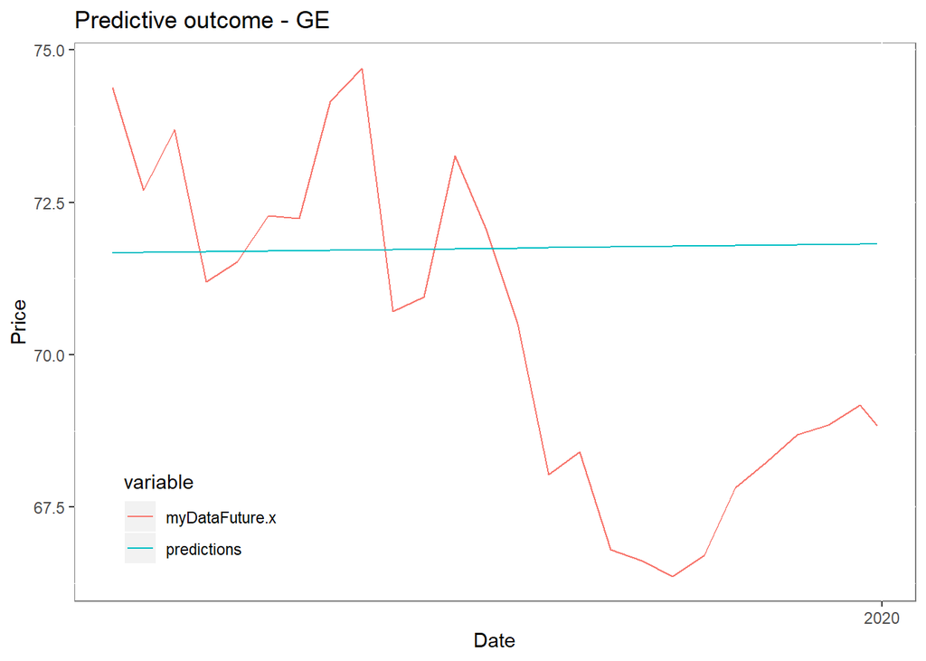

```r
#see predictive power
geData = myDataTrain[length(myDataTrain[,1]-2),1:3]
predictions = c()

for(i in 1:round(length(lagData[,1])*0.10,0)){
  predictions[i] = eval(ge$best$expressions)
  for (cols in (1:(length(geData)-1))){
    geData[cols] = geData[cols+1]
  }
  geData[cols+1] = predictions[i]
}

date = myStockweekly$date[-c(1:(nrows+3))]
df1 = data.frame(date, myDataFuture$x, predictions)
df2 = melt(df1, id.vars='date')
ggplot(data = df2, aes(x=date, y=value, col=variable)) +
  geom_line() +
  ggtitle("Predictive outcome - GE") +
  labs(x = "Date", "Price") +
  scale_x_date(date_breaks = "years", date_labels = "%Y") +
  labs(x = "Date", y = "Price") +
  theme(panel.background = element_rect(fill = "white", colour = "grey50"),legend.position = c(0.15, 0.15))
```

```r
ge2_rmse = rmse(predictions,myDataFuture$x)
```

As observable, the best expression now differs but the prediction are still not really meaningful..  
Finally, instead of testing lags, apply EMAs to see whether this enhances the applicability and predictive power.

```r
# daily
myDataTotal = myStockweekly$close #define dataset

#apply SMAs
lagData = data.frame(x3=SMA(myDataTotal,20), x2=SMA(myDataTotal,10), x1=SMA(myDataTotal,5), myDataTotal)
names(lagData) = c('x3',"x2","x1",'x')
lagData = lagData[-c(1:19),]

nrows = length(lagData[,1])-round(length(lagData[,1])*0.10,0)
myDataFuture = lagData[-c(1:nrows),]
myDataTrain = lagData[c(1:nrows),]

newRules = list(expr = grule(op(expr, expr), func(expr), var),
                func = grule(sin, cos, tan, sqrt),
                op = grule('+', '-', '*', '/', '^'),
                var = grule(geData$x3, geData$x2, geData$x1)) #geData$x5^n, geData$x4^n,
newGram = CreateGrammar(newRules)

geData = myDataTrain
ge = GrammaticalEvolution(newGram, newFitFunc, terminationCost = 0.001, iterations = 5000,disable.warnings=T) #,monitorFunc = print)
ge
```

```
## Grammatical Evolution Search Results:
##   No. Generations:  5000
##   Best Expression:  geData$x1 + sin(geData$x1)/geData$x3
##   Best Cost:        1.56412712519483
```

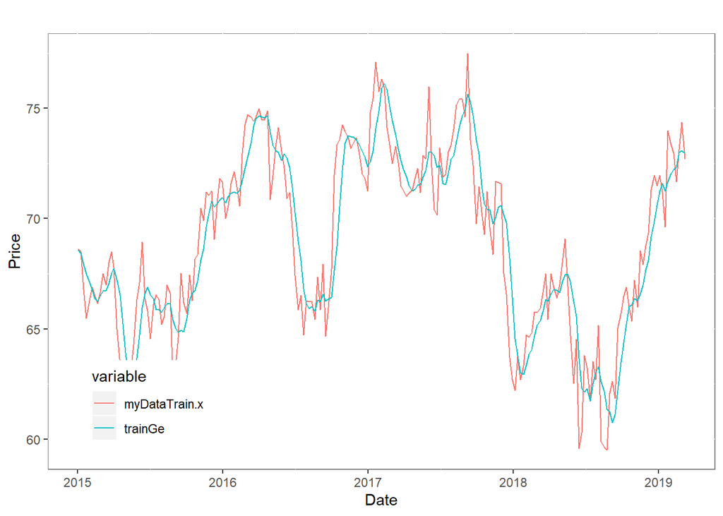

```r
trainGe = eval(ge$best$expressions)

date = myStockweekly$date[c(1:nrows)]
df1 = data.frame(date, myDataTrain$x, trainGe)
df2 = melt(df1, id.vars='date')
ggplot(data = df2, aes(x=date, y=value, col=variable)) +
  geom_line() +
  ggtitle("") +
  labs(x = "Date", "Price") +
  scale_x_date(date_breaks = "years", date_labels = "%Y") +
  labs(x = "Date", y = "Price") +
  theme(panel.background = element_rect(fill = "white", colour = "grey50"),legend.position = c(0.15, 0.15))
```

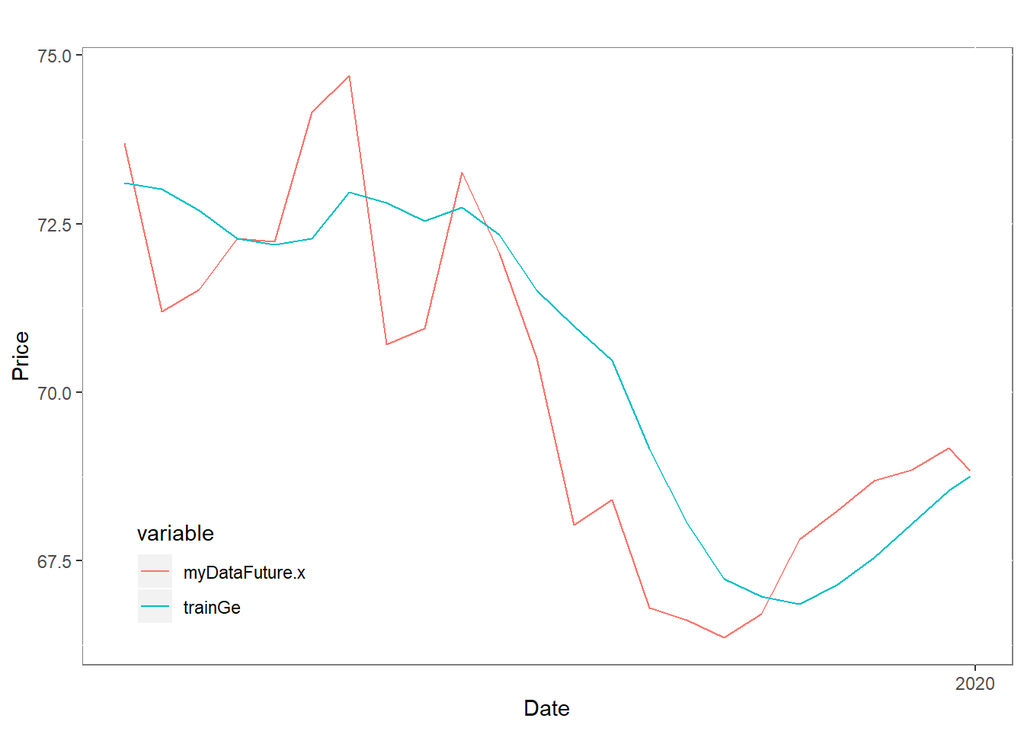

```r
#test formula on unseen data
geData = myDataFuture
trainGe = eval(ge$best$expressions)

date = myStockweekly$date[-c(1:(nrows+19))]
df1 = data.frame(date, myDataFuture$x, trainGe)
df2 = melt(df1, id.vars='date')
ggplot(data = df2, aes(x=date, y=value, col=variable)) +
  geom_line() +
  ggtitle("") +
  labs(x = "Date", "Price") +
  scale_x_date(date_breaks = "years", date_labels = "%Y") +
  labs(x = "Date", y = "Price") +
  theme(panel.background = element_rect(fill = "white", colour = "grey50"),legend.position = c(0.15, 0.15))
```

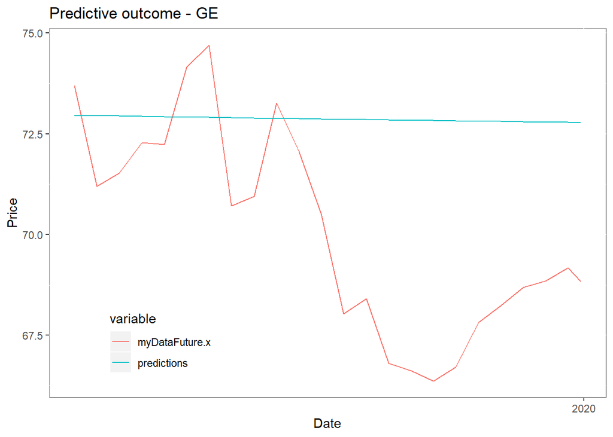

```r
#see predictive power
geData = myDataTrain[length(myDataTrain[,1]-2),1:3]
predictions = c()

for(i in 1:round(length(lagData[,1])*0.10,0)){
  predictions[i] = eval(ge$best$expressions)
  for (cols in (1:(length(geData)-1))){
    geData[cols] = geData[cols+1]
  }
  geData[cols+1] = predictions[i]
}


date = myStockweekly$date[-c(1:(nrows+19))]
df1 = data.frame(date, myDataFuture$x, predictions)
df2 = melt(df1, id.vars='date')
ggplot(data = df2, aes(x=date, y=value, col=variable)) +
  geom_line() +
  ggtitle("Predictive outcome - GE") +
  labs(x = "Date", "Price") +
  scale_x_date(date_breaks = "years", date_labels = "%Y") +
  labs(x = "Date", y = "Price") +
  theme(panel.background = element_rect(fill = "white", colour = "grey50"),legend.position = c(0.2, 0.15))
```

```r
ge3_rmse = rmse(predictions,myDataFuture$x)
```

To draw a conculsion, the Ge is not an applicable tool to predict future stock prices (at least as tested here). The implementation of lags is basically a cheat code for the algorithm, and does fool its actual functioning. The EMA application does not make any difference, yet it shows the Ge´s ability to guess an underlying function. Since there is no real stable trend within the given period, the performance is also weak for predictions.

# Different techniques

As control, test the data with holt-winters…

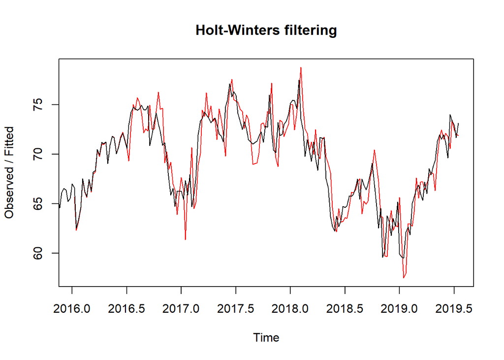

```r
myDataTotal = myStockweekly$close #define dataset
nrows = length(myDataTotal) - round(length(myDataTotal)*0.10,0)
myDataFuture = myDataTotal[-c(1:nrows)]
myDataTrain = myDataTotal[c(1:nrows)]

myTs = ts(myDataTrain, start = c(2015, as.numeric(format(myStock$date[1], "%j"))),frequency = 52)

hw = HoltWinters(myTs)
plot(hw)
```

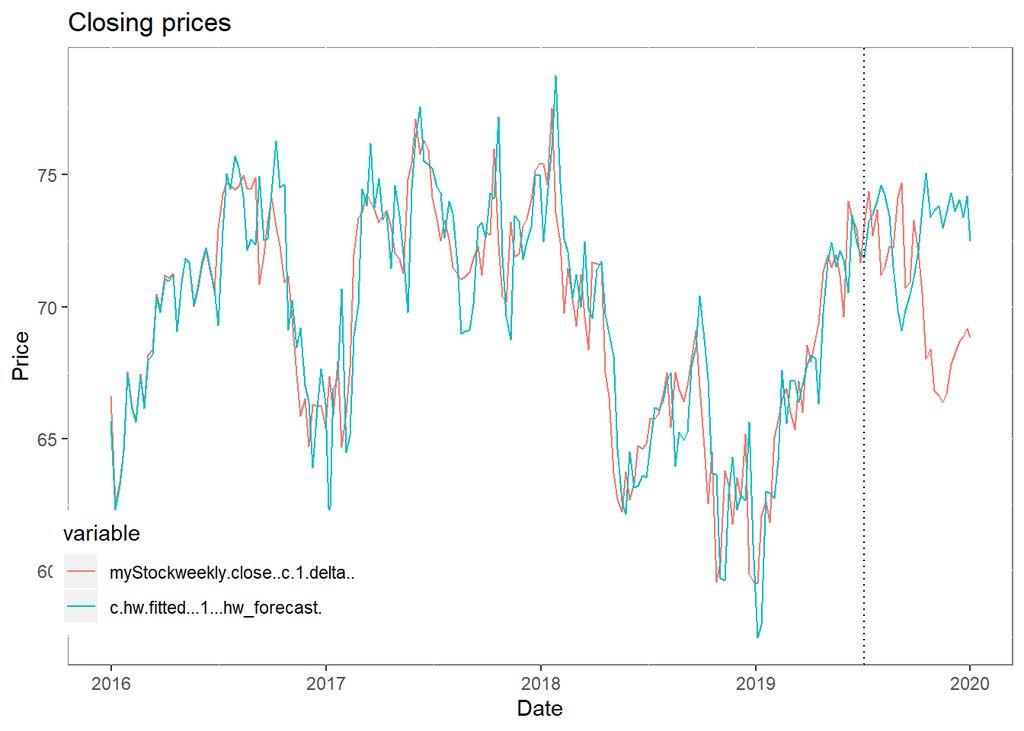

```r
hw_forecast = predict(hw, n.ahead = round(length(myDataTotal)*0.10,0), prediction.interval = F, level = 0.95)
delta = length(myDataTrain)-length(hw$fitted[,1])
date = myStockweekly$date[-c(1:delta)]
df1 = data.frame(date, myStockweekly$close[-c(1:delta)], c(hw$fitted[,1],hw_forecast))
df2 = melt(df1, id.vars='date')
ggplot(data = df2, aes(x=date, y=value, col=variable)) +
  geom_line() +
  geom_vline(xintercept = date[length(hw$fitted[,1])], linetype="dotted") +
  ggtitle("Closing prices") +
  labs(x = "Date", "Price") +
  scale_x_date(date_breaks = "years", date_labels = "%Y") +
  labs(x = "Date", y = "Price") +
  theme(panel.background = element_rect(fill = "white", colour = "grey50"),legend.position = c(0.15, 0.15))
```

```r
hw_rmse = rmse(myDataFuture, hw_forecast)
```

..and auto arima.

```r
model = auto.arima(myTs)

summary(model)
```

```
## Series: myTs
## ARIMA(1,1,1)
##
## Coefficients:
```

```
##          ar1    ma1
##       -0.169  0.049
## s.e.     NaN    NaN
##
## sigma^2 estimated as 2.349:  log likelihood=-432.78
## AIC=871.57   AICc=871.67   BIC=881.95
##
## Training set error measures:
##                      ME     RMSE      MAE          MPE     MAPE      MASE
## Training set 0.01892323 1.522796 1.158038 -0.001152313 1.697426 0.2163633
##                     ACF1
## Training set 0.001324438
```

```r
ar_forecast = forecast(model,round(length(myDataTotal)*0.10,0))
#plot(ar_forecast)
arima_rmse = rmse(myDataFuture, ar_forecast$mean)
```

The Arima model does also perform weak in predicting new data. This might be a hint that the data does not have a clear trend and seasonality to fit the model. I tested two different other stocks (AAPL,ENPH) but yet the results were not different. It seems that stock prices have too much randomness. The HW is the only tested model, actually having “moving” prices thru time yet it performs really weak. The table shows the comparable weekly RMSE (one daily). Finally, the used and tested grammar for SMAs also ended up with the closed “lag”.

```r
RMSE = c(ge1_rmse,ge2_rmse,ge3_rmse,hw_rmse,arima_rmse)
names = c("daily prices - Ge","weekly prices - Ge","weekly SMA - GE","weekly prices - HW","weekly prices autoArima")

kable(data.frame(names,RMSE), caption="RMSE scores")
```

RMSE scores

| names | RMSE |
| --- | --- |
| daily prices - Ge | 3.574031 |
| weekly prices - Ge | 2.959003 |
| weekly SMA - GE | 3.707206 |
| weekly prices - HW | 4.432967 |
| weekly prices autoArima | 3.684004 |